# Problem Set 3 - Boston

SI 544 Instruction Team

11/15/2019

## Introduction

The total score for this assignment will be 100 points, consisting of: - 90 points: Homework Questions - 10 points: Overall quality of spelling, grammar, punctuation, etc. of written sentences.

As in lecture and discussion, there are several ways to approach and answer these questions! There may not be a “best solution”, but instead a variety of ways to interpret and analyze a given task. Be thoughtful in your responses below your code to explain why you chose the methods and representations in your analysis when prompted for a response.

For further reference regarding quality writing, feel free to refer to Strunk & White’s Elements of Style: https://drive.google.com/file/d/1L0P7xJwjUGBvyb49mL3dw1Bt7hzRTiTl/view?usp=sharing

## The Data

The dataset for this assignment was gathered in 1970 in the Boston metropolitan area. Each row corresponds to one US Census tract. These are geographic areas with a few thousand people used by the U.S. government in it’s decennial census of the population. (The help menu entry refers to “towns” in a few places. These should read “census tracts”.) The dataset is the Boston dataset in the MASS package.

Note that the set of entries here is *not* a sample of a larger population of Boston census tracts. It represents all census tracts in Boston (Though each entry itself may be a sample of the larger population in that tract.) We also can not say that Boston represents the entire US, since regions differ. For our purposes, let us assume that these census tracts are a sample of all census tracts in urban areas in the northeastern United States.

```r
## First load some packages and the data. You may have to install the MASS package first.
## Also, note the package load order matters here. MASS and dplyr both have a select function. If you want to use dplyr's select, we need to run it last.
library(MASS)
library(tidyverse)
library(skimr)
library(infer)
library(moderndive)
boston <- Boston
```

### Question 1 (10 Points) DONE

Take a look at the data using one or more of the exploratory data analysis tools and techniques that you’ve learned in SI 544. Make sure to look at the help menu to understand the variables.

Describe the shape of the distribution of the per capita crime rates. What does this say about crime and geography in Boston?

```r
?Boston
```

```
## starting httpd help server ... done
```

```r
glimpse(boston)
```

```
## Observations: 506
## Variables: 14
## $ crim    <dbl> 0.00632, 0.02731, 0.02729, 0.03237, 0.06905, 0.02985, ...
## $ zn      <dbl> 18.0, 0.0, 0.0, 0.0, 0.0, 0.0, 12.5, 12.5, 12.5, 12.5,...
## $ indus   <dbl> 2.31, 7.07, 7.07, 2.18, 2.18, 2.18, 7.87, 7.87, 7.87, ...
## $ chas    <int> 0, 0, 0, 0, 0, 0, 0, 0, 0, 0, 0, 0, 0, 0, 0, 0, 0, 0, ...
## $ nox     <dbl> 0.538, 0.469, 0.469, 0.458, 0.458, 0.458, 0.524, 0.524...
## $ rm      <dbl> 6.575, 6.421, 7.185, 6.998, 7.147, 6.430, 6.012, 6.172...
## $ age     <dbl> 65.2, 78.9, 61.1, 45.8, 54.2, 58.7, 66.6, 96.1, 100.0,...
## $ dis     <dbl> 4.0900, 4.9671, 4.9671, 6.0622, 6.0622, 6.0622, 5.5605...
## $ rad     <int> 1, 2, 2, 3, 3, 3, 5, 5, 5, 5, 5, 5, 5, 4, 4, 4, 4, 4, ...
## $ tax     <dbl> 296, 242, 242, 222, 222, 222, 311, 311, 311, 311, 311,...
## $ ptratio <dbl> 15.3, 17.8, 17.8, 18.7, 18.7, 18.7, 15.2, 15.2, 15.2, ...
## $ black   <dbl> 396.90, 396.90, 392.83, 394.63, 396.90, 394.12, 395.60...
## $ lstat   <dbl> 4.98, 9.14, 4.03, 2.94, 5.33, 5.21, 12.43, 19.15, 29.9...
## $ medv    <dbl> 24.0, 21.6, 34.7, 33.4, 36.2, 28.7, 22.9, 27.1, 16.5, ...
```

```r
sample_n(boston, size = 5)
```

```
##      crim zn indus chas   nox    rm  age    dis rad tax ptratio  black
## 1 0.07151  0  4.49    0 0.449 6.121 56.8 3.7476   3 247    18.5 395.15
## 2 0.54011 20  3.97    0 0.647 7.203 81.8 2.1121   5 264    13.0 392.80
## 3 0.02731  0  7.07    0 0.469 6.421 78.9 4.9671   2 242    17.8 396.90
## 4 0.11432  0  8.56    0 0.520 6.781 71.3 2.8561   5 384    20.9 395.58
## 5 0.09266 34  6.09    0 0.433 6.495 18.4 5.4917   7 329    16.1 383.61
##   lstat medv
## 1  8.44 22.2
## 2  9.59 33.8
## 3  9.14 21.6
## 4  7.67 26.5
## 5  8.67 26.4
```

```r
boston %>% skim()
```

```
## Skim summary statistics
##  n obs: 506
##  n variables: 14
##
## -- Variable type:integer -----------------------------------------------------------------------------------------------------
##  variable missing complete   n  mean   sd p0 p25 p50 p75 p100     hist
##      chas       0      506 506 0.069 0.25  0   0   0   0    1 ▇▁▁▁▁▁▁▁
##       rad       0      506 506 9.55  8.71  1   4   5  24   24 ▂▇▁▁▁▁▁▅
##
## -- Variable type:numeric -----------------------------------------------------------------------------------------------------
##  variable missing complete   n   mean     sd       p0     p25    p50
##       age       0      506 506  68.57  28.15   2.9     45.02   77.5
##     black       0      506 506 356.67  91.29   0.32   375.38  391.44
##      crim       0      506 506   3.61   8.6    0.0063   0.082   0.26
##       dis       0      506 506   3.8    2.11   1.13     2.1     3.21
##     indus       0      506 506  11.14   6.86   0.46     5.19    9.69
##     lstat       0      506 506  12.65   7.14   1.73     6.95   11.36
##      medv       0      506 506  22.53   9.2    5       17.02   21.2
##       nox       0      506 506   0.55   0.12   0.38     0.45    0.54
##   ptratio       0      506 506  18.46   2.16  12.6     17.4    19.05
##        rm       0      506 506   6.28   0.7    3.56     5.89    6.21
##       tax       0      506 506 408.24 168.54 187      279     330
##        zn       0      506 506  11.36  23.32   0        0       0
##     p75   p100     hist
##   94.07 100    ▁▂▂▂▂▂▃▇
##  396.23 396.9  ▁▁▁▁▁▁▁▇
##    3.68  88.98 ▇▁▁▁▁▁▁▁
##    5.19  12.13 ▇▅▃▃▂▁▁▁
##   18.1   27.74 ▃▆▅▁▁▇▁▁
##   16.96  37.97 ▆▇▆▅▂▁▁▁
##   25     50    ▂▅▇▆▂▂▁▁
##    0.62   0.87 ▇▆▇▆▃▅▁▁
##   20.2   22    ▁▂▂▂▅▅▇▃
##    6.62   8.78 ▁▁▂▇▇▂▁▁
##  666    711    ▃▇▂▅▁▁▁▆
##   12.5  100    ▇▁▁▁▁▁▁▁
```

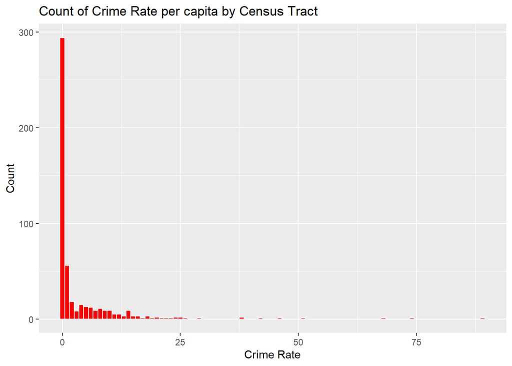

```r
ggplot(boston, aes(x=crim))+
  geom_histogram(color = 'white', fill = 'red', binwidth = 1)+
  labs(x = "Crime Rate", y = "Count", title = "Count of Crime Rate per capita by Census Tract")
```

```r
boston %>%
  summarize(median_crm = median(crim), mean_crm = mean(crim))
```

```
##   median_crm mean_crm
## 1    0.25651 3.613524
```

#### Q1 Response

To explore the data, I first brought up the help menu with ?Boston to get an understanding for what each of the variables in the data are. After reading those, I used glimpse() and sample_n() to get an understanding of some of the values associated with the variables. Lastly, I used the skim() function to view summary statistics for each variable.

To view the distribution of crime rates, I created a histogram with ggplot. I selected a binwidth of 1 because the bars of the histogram become exceptionally difficult to see with anything lower.

Observing the plot, the distribution of crime rates according to geography in boston is right skewed. The vast majority of per capita crime rates are clustered around 0 and decrease sharply for every 1 positive unit away from one. There are a few outliers where the crime rates are VERY high. This can be confirmed visually and by observing the mean compared to the median for the distribution. The median of 0.257 is much more representative of the center of the distribution of crime rates as opposed to the mean of 3.614, which is being pulled much higher due to outliers. Overall, this indicates that crime in Boston is generally low, except for a few particular places where there is significantly more crime.

### Question 2 (10 Points)

Use bootstrapping with the percentile method to compute a 95% confidence interval for the average pupil-teacher ratio in urban, northeastern United States. Interpret your results in a complete sentence that a non-statistician would understand.

```r
set.seed(2019)

pupil_teacher_bootstrap <- boston %>%
  specify(response = ptratio) %>%
  generate(reps = 1000) %>%
  calculate(stat = "mean")
```

```
## Setting `type = "bootstrap"` in `generate()`.
```

```r
percentile_confidence_interval_pupil <- pupil_teacher_bootstrap %>%
  get_confidence_interval(level = 0.95, type = "percentile")

percentile_confidence_interval_pupil
```

```
## # A tibble: 1 x 2
##   `2.5%` `97.5%`
##    <dbl>   <dbl>
## 1   18.3    18.6
```

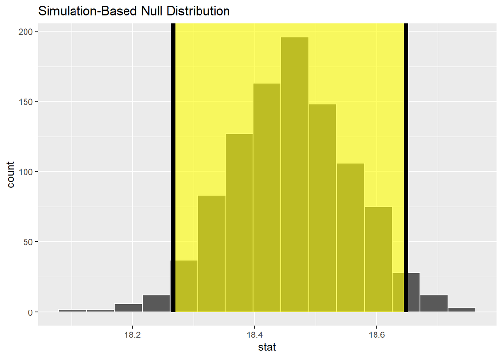

```r
visualize(pupil_teacher_bootstrap)+
  shade_ci(endpoints = percentile_confidence_interval_pupil, fill = 'yellow', color = 'black')
```

#### Q2 Response

To do a bootstrap with the percentile method, I first set a seed to guarantee the results displayed are not changed via random number generation. I created a new variable assigning it the boston data set and specified the respone variable, generated 1000 replicates (with replacement), and calculated the mean of that distribution. Then, I used the get_confidence_interval function bounded to 95% confidence and fed in the bootstrap created before. To view the confidence interval overlayed on the bootstrap distribution, I used the visualize() function with the shade_ci() function.

Interpreting this in a way that a non-statistician would understand, we could say, “We are 95% confident that the average ratio of pupils to teachers in the urban northeastern United States is between 18.2658 and 18.64407.”

### Question 3 (10 Points)

Use the traditional method, using a t-distribution, to compute a 95% confidence interval for the average pupil-teacher ratio in urban, northeastern United States. (You can use t*=1.96.)

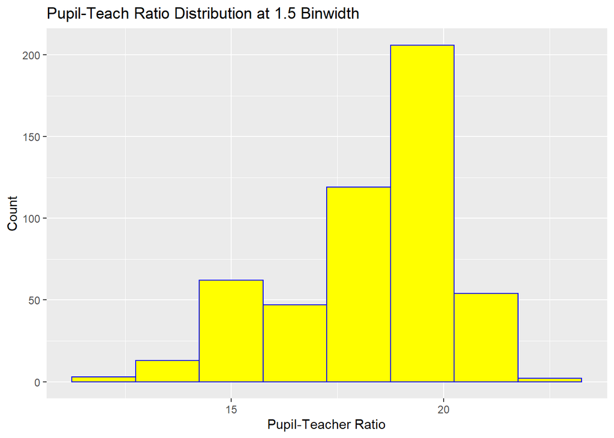

```r
?Boston

ggplot(boston, aes(x = ptratio))+
  geom_histogram(binwidth = 1.5, color = "blue", fill = "yellow")+
  labs(x = "Pupil-Teacher Ratio", y = "Count", title = "Pupil-Teach Ratio Distribution at 1.5 Binwidth")
```

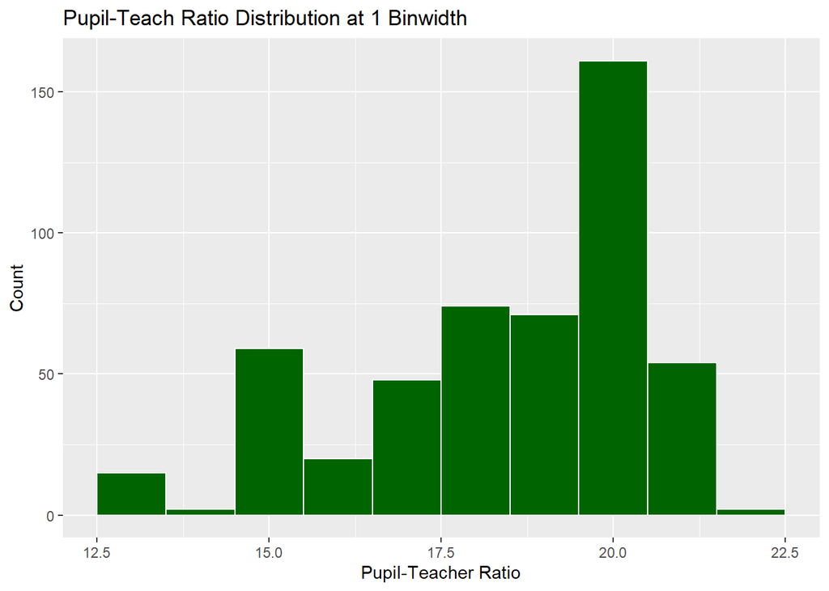

```r
ggplot(boston, aes(x = ptratio))+
  geom_histogram(binwidth = 1, color = "white", fill = "darkgreen")+
  labs(x = "Pupil-Teacher Ratio", y = "Count", title = "Pupil-Teach Ratio Distribution at 1 Binwidth")
```

```r
pupil_teacher_summary <- boston %>%
  summarize(mean = mean(ptratio), std_dev = sd(ptratio), n = n())
pupil_teacher_summary
```

```
##       mean  std_dev   n
## 1 18.45553 2.164946 506
```

```r
pupil_teacher_full_values <-  pupil_teacher_summary %>%
  mutate(standard_error = pupil_teacher_summary$std_dev / sqrt(pupil_teacher_summary$n))

pupil_teacher_full_values
```

```
##       mean  std_dev   n standard_error
## 1 18.45553 2.164946 506     0.09624357
```

```r
pupil_teacher_confidence_interval <- pupil_teacher_full_values %>%
  mutate(
         lower_confidence_bound = pupil_teacher_full_values$mean - (1.96 * pupil_teacher_full_values$standard_error),
         upper_confidence_bound = pupil_teacher_full_values$mean + (1.96 * pupil_teacher_full_values$standard_error)
         )

pupil_teacher_confidence_interval[1,5:6]
```

```
##   lower_confidence_bound upper_confidence_bound
## 1                18.2669               18.64417
```

#### Q3 Response

In order to compute a t-test with the traditional method, we must check for independence in the collection of observations and approximate normality in the sample. Although not specified, the ptratio appears to pass the independence check because the census tracts are based geographically. Assuming there is no overlap in geography where places are being sampled twice, we can say that these observations are independent.

As for approximate normality of the distribution, the sample is CLOSE to normal depending on your binwidth selected for the histogram. To visualize this difference I used ggplot to create two histograms, one with a binwidth of 1.5 and the other with a binwidth of 1. With a binwidth of 1.5 we see a distribution that looks relatively normal. However, with a 1 binwidth the data begins to stray from normality. It’s unclear whether we should use a t-test here, but because this isn’t an egregiously non-normal distribution and there is a larger sample size, the test can be performed.

To compute the 95% confidence interval using traditional methods I used the formula xbar +- t * s/sqrt(n). To find those values, I used the summarize function to calculate mean, standard deviation, and n. From there, I calculated the standard error using the formula sigma/sqrt(n) and found the upper and lower bounds by using the first formula. The values for the lower and upper bounds forming the confidence interval are 18.2669 and 18.64417 respectively. Thus, we are 95% confident that the true population mean of pupil to teacher ratios in the urban northeastern United States is between 18.2669 and 18.64417.

### Question 4 (10 Points)

Assume that urban northeastern US property tax rates are currently around 1.054%. (Actually, this is Boston. Just go with it.) We would like to know if urban northeastern US property tax rates are higher today than they were in 1970.

Set up (but don’t run it yet) a hypothesis test to examine this question. What are your null and alternative hypotheses? What is the cut-off for a p-value that you will use to reject the null?

#### Q4 Response

Null Hypothesis: Current urban northeastern US property tax rates are the same as they were in 1970.

Hnaught: Mu(tax rate in 1970) = 1.054%

1.054%

Alternative Hypothesis: Urban northeastern US property tax rates in 1970 are less than current urban norhteastern US property tax rates

Ha: Mu(tax rate in 1970) < 1.054%

Cut-off p-value (alpha): 0.05

### Question 5 (10 Points)

Use the traditional method, with a test-statistic, to calculate the p-value for the hypothesis test you wrote out in Question 4. Write your conclusion in a few complete sentences that would make sense to a random Boston citizen.

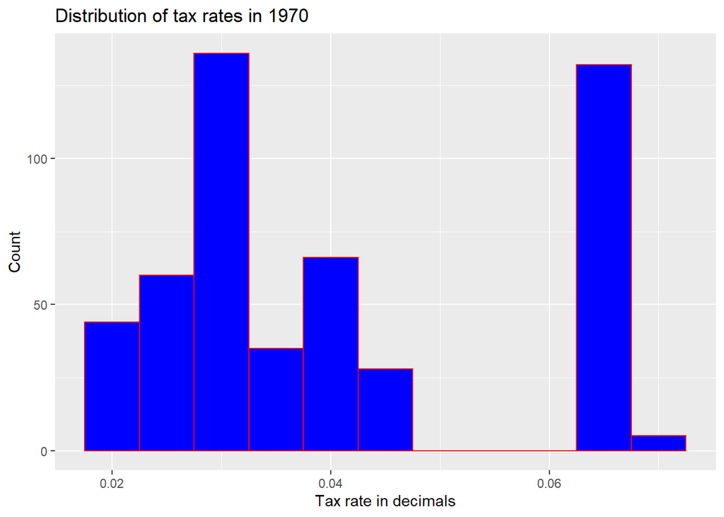

```r
boston <- boston %>%
  mutate(tax_percent = tax/10000 )

ggplot(boston, aes(x = tax_percent))+
  geom_histogram(color = 'red', fill = 'blue', binwidth = 0.005)+
  labs(title = "Distribution of tax rates in 1970", x = "Tax rate in decimals", y = "Count")
```

```r
tax_rate_values <- boston %>%
  summarize(mean = mean(tax_percent), std_dev = sd(tax_percent), n = n())
tax_rate_values
```

```
##         mean    std_dev   n
## 1 0.04082372 0.01685371 506
```

```r
tax_rate_values <- tax_rate_values %>%
  mutate(std_error = tax_rate_values$std_dev / sqrt(tax_rate_values$n),
         t = (tax_rate_values$mean - 0.01054) / (tax_rate_values$std_dev/sqrt(tax_rate_values$n)),
         t_df = tax_rate_values$n - 1)
tax_rate_values
```

```
##         mean    std_dev   n    std_error        t t_df
## 1 0.04082372 0.01685371 506 0.0007492389 40.41931  505
```

```r
tax_rate_p_val <- pt(0.01054, tax_rate_values$t_df, tax_rate_values$t,
                     lower.tail = FALSE)
tax_rate_p_val
```

```
## [1] 1
```

#### Q5 Response

To perform a traditional T-test, we first need to check for independence of observations and approximate normality in distribution. Given these rates are geographical (assuming no overlap in calculation), this data passes the independence test. Approximate normality, however, does not fare as well. Looking at the distribution created with ggplot above, we see a relatively clear gap between 0.05 and 0.065. Squinting as hard as you possibly can, this distribution is still not normal. Using traditional methods to compute a p value is ill advised at best, but lets perform one to see the results anyways.

To perform this test, I made a new variable with the tax rates in decimal form using mutate. From there, I calculated values necessary for the test statistic in tax_rate_values. I fed those values into the pt() formula to calculate a p value. With a p-value of one, we do not have sufficient evidence to reject the null hypothesis that the tax rate in 1970 is less than the current (assumed) tax rate of 1.054%

Stating this in a way that a random boston citizen could understand, we could say, “We wanted to know whether tax rates are higher now than they were in the 1970s. Lets pretend that they are equal and look at data we have from the 1970s and see if that supports our claim that they are equal. Given our data, we have no evidence to reject that claim that they are equal because we would not be surprised to see an average tax rate that we have calculated with the data we have.”

### Question 6 (10 Points)

Use the infer package to calculate the p-value for the hypothesis test you wrote out in Question 4. Write your conclusion in a few complete sentences that would make sense to a random Boston citizen. Hint: Look at the ModernDive textbook, Appendix B.2.4.

```r
x_bar_tax_rate <- boston %>%
  specify(response = tax_percent)%>%
  calculate(stat = "mean")

x_bar_tax_rate
```

```
## # A tibble: 1 x 1
##     stat
##    <dbl>
## 1 0.0408
```

```r
null_dist_tax_rate <- boston%>%
  specify(response = tax_percent)%>%
  hypothesize(null = "point", mu = x_bar_tax_rate$stat)%>%
  generate(reps = 1000)%>%
  calculate(stat = "mean")
```

```
## Setting `type = "bootstrap"` in `generate()`.
```

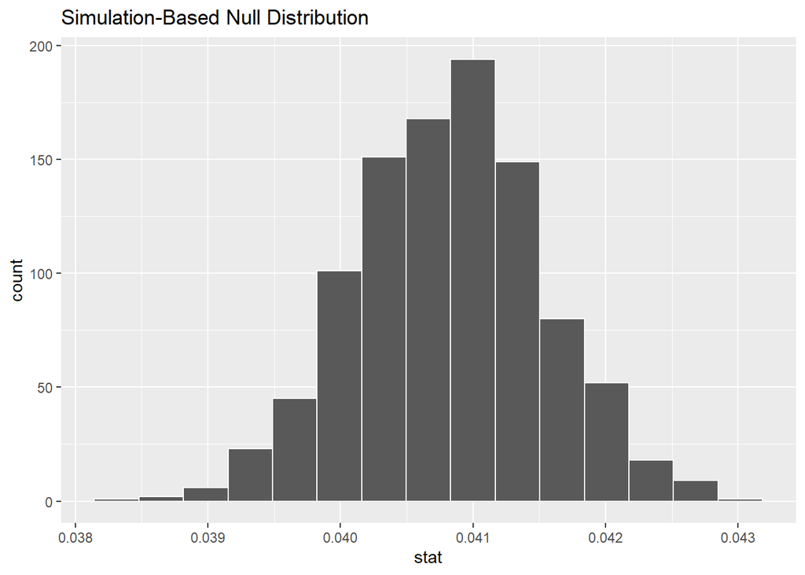

```r
null_dist_tax_rate %>% visualize()
```

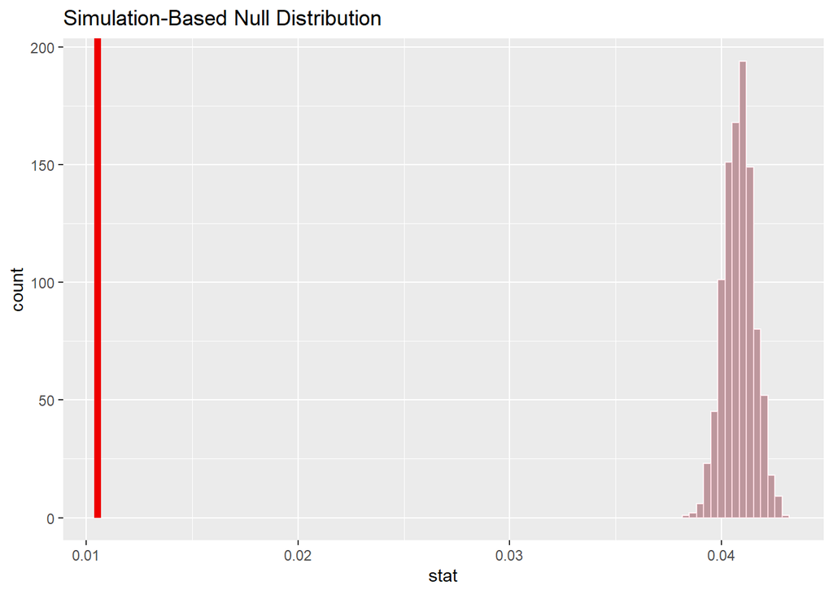

```r
null_dist_tax_rate %>%
  visualize(obs_stat = 0.01054, direction = "greater")
```

```r
pvalue <- null_dist_tax_rate %>%
  get_pvalue(obs_stat = 0.01054, direction = "greater")
pvalue
```

```
## # A tibble: 1 x 1
##   p_value
##     <dbl>
## 1       1
```

#### Q6 Response

To calculate the p value for the hypothesis test in question 4, I used a bootstrapped sample of the tax rate and calculated the mean of the sample. I fed that through the infer pipeline and visualized the distribution of the bootstrapped sample. With that bootstrapped sample, I visualized the p value and got the p value using the get_p_value function.

Explaining this to a random Boston citizen, we could say "We wanted to know whether tax rates are higher now than they were in the 1970s. However, our data that we collected doesn’t meet the conditions necessary to use a formula that we need to use. Fortunately, we can use computers to make a bunch of extra data for us that mimics a bigger data set by using the data we already have. After the computer generates a bunch of samples for us, lets see whether or not we can say if tax rates are higher now than they were in the 1970s. Lets assume that the tax rates now are equal to what they were in the 1970s and look at what the computer generated and see if that can support our statement. Looking at the graph, we would not be surprised at all to see a value like the one we saw, so we can’t reject our statement that they are equal.

### Question 7 (10 Points)

Now we are curious about what traits are related to high-crime areas. Run a regression that predicts per capita crime rate based on the following variables: zn, chas, nox, rm, age, dis, and rad.

1. Make sure that your regression table or regression summary is visible in your knit document. (b) Which variables don’t seem to be (statistically significantly) related to per capita crime rates? Write your answer in sentences that would make sense to a random Boston citizen. (c) What is the R^2 value?

```r
high_crime_regression <- lm(crim ~ zn + chas + nox + rm + age + dis + rad,data = boston)

get_regression_table(high_crime_regression)
```

```
## # A tibble: 8 x 7
##   term      estimate std_error statistic p_value lower_ci upper_ci
##   <chr>        <dbl>     <dbl>     <dbl>   <dbl>    <dbl>    <dbl>
## 1 intercept    9.47      4.64       2.04   0.042    0.352   18.6
## 2 zn           0.044     0.018      2.48   0.014    0.009    0.078
## 3 chas        -1.80      1.18      -1.52   0.128   -4.11     0.519
## 4 nox         -4.90      4.74      -1.03   0.303  -14.2      4.43
## 5 rm          -1.25      0.458     -2.73   0.006   -2.15    -0.352
## 6 age          0.021     0.017      1.23   0.221   -0.013    0.055
## 7 dis         -0.652     0.269     -2.42   0.016   -1.18    -0.124
## 8 rad          0.564     0.043     13.1    0        0.479    0.648
```

```r
get_regression_summaries(high_crime_regression)
```

```
## # A tibble: 1 x 8
##   r_squared adj_r_squared   mse  rmse sigma statistic p_value    df
##       <dbl>         <dbl> <dbl> <dbl> <dbl>     <dbl>   <dbl> <dbl>
## 1     0.416         0.407  43.1  6.57  6.62      50.6       0     8
```

```r
reg_pts <- get_regression_points(high_crime_regression)
reg_pts
```

```
## # A tibble: 506 x 11
##       ID  crim    zn  chas   nox    rm   age   dis   rad crim_hat residual
##    <int> <dbl> <dbl> <int> <dbl> <dbl> <dbl> <dbl> <int>    <dbl>    <dbl>
##  1     1 0.006  18       0 0.538  6.58  65.2  4.09     1   -1.34     1.34
##  2     2 0.027   0       0 0.469  6.42  78.9  4.97     2   -1.31     1.34
##  3     3 0.027   0       0 0.469  7.18  61.1  4.97     2   -2.64     2.67
##  4     4 0.032   0       0 0.458  7.00  45.8  6.06     3   -2.83     2.86
##  5     5 0.069   0       0 0.458  7.15  54.2  6.06     3   -2.84     2.90
##  6     6 0.03    0       0 0.458  6.43  58.7  6.06     3   -1.84     1.87
##  7     7 0.088  12.5     0 0.524  6.01  66.6  5.56     5    0.522   -0.434
##  8     8 0.145  12.5     0 0.524  6.17  96.1  5.95     5    0.688   -0.543
##  9     9 0.211  12.5     0 0.524  5.63 100    6.08     5    1.36    -1.15
## 10    10 0.17   12.5     0 0.524  6.00  85.9  6.59     5    0.265   -0.095
## # ... with 496 more rows
```

#### Q7 Response

Looking at the p_value column, there are several variables that do not appear to be statistically significant. With an alpha value of 0.05 any variable that is less than 0.05 is statistically significant. That said, the variables that are not statistically significant are chas, nox, and age.

The R^2 value is 0.416.

Explaining this in a way that a random Boston citizen would understand, we could say:

We have a bunch of data and we want to see if that data has a relationship with per capita crime rates in the urban northeastern United States. We did some fancy math and got a bunch of values about those variables and their relationship to per capita crime rates. All of the values come back with a “p value” which states whether or not that relationship is by chance or not. If the p value is less than 0.05, then we say can say with some level of certainty that the relationship is not by chance. That said, our values that ARE by chance are chas, nox, and age. The rest are not by chance and likely have some relationship to per capita crime rate.

### Question 8 (10 Points)

Remember how the distribution of per capita crime looked? This means that the data is right-skewed. In cases like this we might try log-transforming the data. If we find a stronger statistical relationship with the log-transformed data, then there might be an exponential process that generated the original data. (Because logarithms undo exponents.) For example if you suspect that the relationship between variables x and y is $y=a*b^x$, then the log-transformed equation is $log(y)=log(a)+x*log(b)$ or, rewriting the constants, $log(y)=A + Bx$. So x and log(y) will be linearly related, and we can do a linear regression. For more more details on logarithms, you can check out: https://www.statisticshowto.datasciencecentral.com/probability-and-statistics/statistics-definitions/logarithms/

Create a new variable in the boston data frame called log_crim. This should be the natural logarithm of the per capita crime rate. Then run the regression that you ran in the previous problem, except replace crim with log_crim.

1. Make sure that your regression table or regression summary is visible in your knit document. (b) Which variables don’t seem to be (statistically significantly) related to the logarithm of per capita crime rates? Write your answer in sentences that would make sense to a random Boston citizen.

```r
boston <- boston %>%
  mutate(log_crim = log(crim))

high_crime_log_regression <- lm(log_crim ~ zn + chas + nox + rm + age + dis + rad,data = boston)

get_regression_table(high_crime_log_regression)
```

```
## # A tibble: 8 x 7
##   term      estimate std_error statistic p_value lower_ci upper_ci
##   <chr>        <dbl>     <dbl>     <dbl>   <dbl>    <dbl>    <dbl>
## 1 intercept   -4.38      0.559    -7.83    0       -5.47    -3.28
## 2 zn          -0.01      0.002    -4.51    0       -0.014   -0.005
## 3 chas        -0.036     0.142    -0.256   0.798   -0.315    0.242
## 4 nox          4.82      0.571     8.44    0        3.70     5.94
## 5 rm          -0.123     0.055    -2.23    0.026   -0.231   -0.015
## 6 age          0.008     0.002     3.91    0        0.004    0.012
## 7 dis         -0.038     0.032    -1.18    0.24    -0.102    0.025
## 8 rad          0.146     0.005    28.2     0        0.136    0.156
```

```r
get_regression_summaries(high_crime_log_regression)
```

```
## # A tibble: 1 x 8
##   r_squared adj_r_squared   mse  rmse sigma statistic p_value    df
##       <dbl>         <dbl> <dbl> <dbl> <dbl>     <dbl>   <dbl> <dbl>
## 1     0.866         0.864 0.625 0.791 0.797      460.       0     8
```

```r
reg_pts_log <- get_regression_points(high_crime_log_regression)
reg_pts_log
```

```
## # A tibble: 506 x 11
##       ID log_crim    zn  chas   nox    rm   age   dis   rad log_crim_hat
##    <int>    <dbl> <dbl> <int> <dbl> <dbl> <dbl> <dbl> <int>        <dbl>
##  1     1    -5.06  18       0 0.538  6.58  65.2  4.09     1        -2.24
##  2     2    -3.60   0       0 0.469  6.42  78.9  4.97     2        -2.16
##  3     3    -3.60   0       0 0.469  7.18  61.1  4.97     2        -2.40
##  4     4    -3.43   0       0 0.458  7.00  45.8  6.06     3        -2.45
##  5     5    -2.67   0       0 0.458  7.15  54.2  6.06     3        -2.40
##  6     6    -3.51   0       0 0.458  6.43  58.7  6.06     3        -2.28
##  7     7    -2.43  12.5     0 0.524  6.01  66.6  5.56     5        -1.65
##  8     8    -1.93  12.5     0 0.524  6.17  96.1  5.95     5        -1.45
##  9     9    -1.56  12.5     0 0.524  5.63 100    6.08     5        -1.35
## 10    10    -1.77  12.5     0 0.524  6.00  85.9  6.59     5        -1.53
## # ... with 496 more rows, and 1 more variable: residual <dbl>
```

#### Q8 Response

Continuing our explanation from 7 to a random Boston Citizen, we could say:

Sometimes values in our data don’t fit correctly for the math that we need to used for them, so we transform all of the data with some other math to see whether or not that model is better. We used a “logarithmic” function on all of our data points and looked to see whether there is a relationship between per capita crime rates and all of the other pieces of data that we have. We can say that the relationship is not by chance if we see a “p value” of less than 0.05 from our calculation. In our data, we see 2 variables that have a p value greater than 0.05. Those variables are chas and dis. That means that chas and dis are likely showing a relationship, but that relationship is not significant because it is by chance. The other values, however, do likely have a relationship that is not by chance.

Additionally, our model has an R^2 value that explains the amount of “weirdness” in our data. I.E. the distance that our data doesn’t match what we expected. Our R^2 value is 0.866, meaning that 86.6% of the deviation from what we expect is explained by our model. By statistics standards, that’s a pretty good model.

### Question 9 (10 points)

Compare the R^2 values of the two regressions from Q7 and Q8. Which regression seems to have a stronger relationship? Should we use crim or log_crim in future analysis? (You should also be able to support your explanation by looking at graphs of the residuals for each regression. Though you don’t have to do that here.)

```r
reg_pts
```

```
## # A tibble: 506 x 11
##       ID  crim    zn  chas   nox    rm   age   dis   rad crim_hat residual
##    <int> <dbl> <dbl> <int> <dbl> <dbl> <dbl> <dbl> <int>    <dbl>    <dbl>
##  1     1 0.006  18       0 0.538  6.58  65.2  4.09     1   -1.34     1.34
##  2     2 0.027   0       0 0.469  6.42  78.9  4.97     2   -1.31     1.34
##  3     3 0.027   0       0 0.469  7.18  61.1  4.97     2   -2.64     2.67
##  4     4 0.032   0       0 0.458  7.00  45.8  6.06     3   -2.83     2.86
##  5     5 0.069   0       0 0.458  7.15  54.2  6.06     3   -2.84     2.90
##  6     6 0.03    0       0 0.458  6.43  58.7  6.06     3   -1.84     1.87
##  7     7 0.088  12.5     0 0.524  6.01  66.6  5.56     5    0.522   -0.434
##  8     8 0.145  12.5     0 0.524  6.17  96.1  5.95     5    0.688   -0.543
##  9     9 0.211  12.5     0 0.524  5.63 100    6.08     5    1.36    -1.15
## 10    10 0.17   12.5     0 0.524  6.00  85.9  6.59     5    0.265   -0.095
## # ... with 496 more rows
```

```r
reg_pts_log
```

```
## # A tibble: 506 x 11
##       ID log_crim    zn  chas   nox    rm   age   dis   rad log_crim_hat
##    <int>    <dbl> <dbl> <int> <dbl> <dbl> <dbl> <dbl> <int>        <dbl>
##  1     1    -5.06  18       0 0.538  6.58  65.2  4.09     1        -2.24
##  2     2    -3.60   0       0 0.469  6.42  78.9  4.97     2        -2.16
##  3     3    -3.60   0       0 0.469  7.18  61.1  4.97     2        -2.40
##  4     4    -3.43   0       0 0.458  7.00  45.8  6.06     3        -2.45
##  5     5    -2.67   0       0 0.458  7.15  54.2  6.06     3        -2.40
##  6     6    -3.51   0       0 0.458  6.43  58.7  6.06     3        -2.28
##  7     7    -2.43  12.5     0 0.524  6.01  66.6  5.56     5        -1.65
##  8     8    -1.93  12.5     0 0.524  6.17  96.1  5.95     5        -1.45
##  9     9    -1.56  12.5     0 0.524  5.63 100    6.08     5        -1.35
## 10    10    -1.77  12.5     0 0.524  6.00  85.9  6.59     5        -1.53
## # ... with 496 more rows, and 1 more variable: residual <dbl>
```

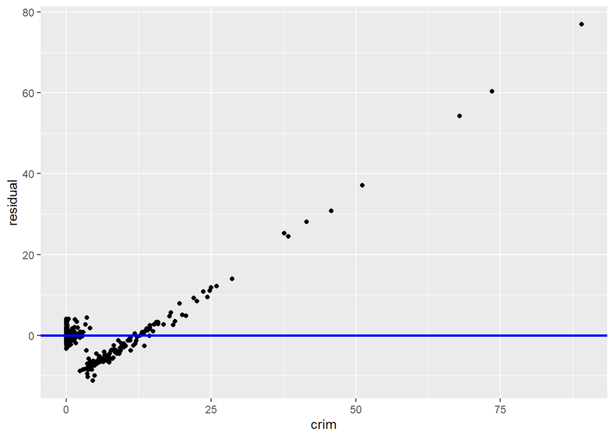

```r
ggplot(reg_pts, aes(x = crim, y = residual))+
  geom_point()+
   geom_hline(yintercept = 0, col = "blue", size = 1)
```

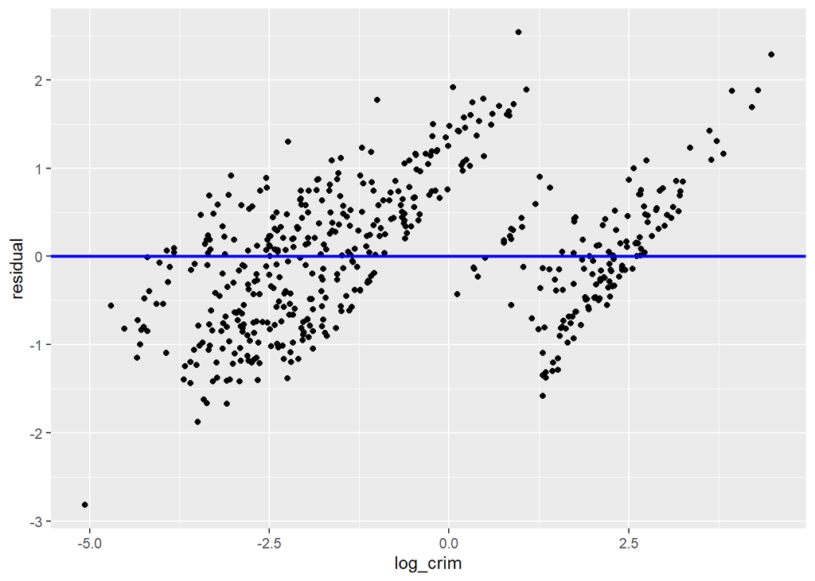

```r
ggplot(reg_pts_log, aes(x = log_crim, y = residual))+
  geom_point()+
   geom_hline(yintercept = 0, col = "blue", size = 1)
```

#### Q9 Response

From our two models, the logarithmic model provides a stronger relationship because the R^2 value is higher, meaning that more of the variance in the model is explained. With the logarithmic model we will be able to make better inferences about the data because less of those inferences are going to be subject to random deviations from our predicted values for the model. Thus, it is likely a better model and ought to be used over the non-logarithmic version. Additionally, if we look at the residuals for the non logarithmic model, we can see that there is a clear pattern in variance, thus violating the E in the LINE check. Looking at the residuals in the logarithmic model, the distribution of variance is much less patterned indicating that is a better model for inference.